# Data Science Project

James Li

06/30/24

# Introduction

The purpose of this project is to gauge your technical skills and problem solving ability by working through something similar to a real NBA data science project. You will work your way through this R Markdown document, answering questions as you go along. Please begin by adding your name to the “author” key in the YAML header. When you’re finished with the document, come back and type your answers into the answer key at the top. Please leave all your work below and have your answers where indicated below as well. Please note that we will be reviewing your code so make it clear, concise and avoid long printouts. Feel free to add in as many new code chunks as you’d like.

Remember that we will be grading the quality of your code and visuals alongside the correctness of your answers. Please try to use the tidyverse as much as possible (instead of base R and explicit loops). Please do not bring in any outside data.

**Note:**

**Throughout this document, any `season` column represents the year each season started. For example, the 2015-16 season will be in the dataset as 2015. For most of the rest of the project, we will refer to a season by just this number (e.g. 2015) instead of the full text (e.g. 2015-16).**

# Answers

## Part 1

**Question 1:**

- Offensive: 56.5% eFG
- Defensive: 47.9% eFG

**Question 2:** 81.7%

**Question 3:** 46.2%

**Question 4:** This is a written question. Please leave your response in the document under Question 5.

**Question 5:** 94.3% of games

**Question 6:**

- Round 1: 60.1%
- Round 2: 60.2%
- Conference Finals: 58.4%
- Finals: 52.9%

**Question 7:**

- Percent of +5.0 net rating teams making the 2nd round next year: 61.76%
- Percent of top 5 minutes played players who played in those 2nd round series: 35.2%

## Part 2

Please show your work in the document, you don’t need anything here.

## Part 3

Please write your response in the document, you don’t need anything here.

# Setup and Data

```r
library(tidyverse)
# Note, you will likely have to change these paths. If your data is in the same folder as this project,
# the paths will likely be fixed for you by deleting ../../Data/awards_project/ from each string.
# player_data <- read_csv("../../Data/playoffs_project/player_data.csv")
# team_data <- read_csv("../../Data/playoffs_project/team_data.csv")
```

## Part 1 – Data Cleaning

In this section, you’re going to work to answer questions using data from both team and player stats. All provided stats are on the game level.

### Question 1

**QUESTION:** What was the Warriors’ Team offensive and defensive eFG% in the 2015-16 regular season? Remember that this is in the data as the 2015 season.

```r
file.choose()
```

```
## [1] "C:\\Users\\James\\OneDrive\\桌面\\Thunder Project\\Thunder_up_final.html"
```

```r
install.packages("dplyr")
library(dplyr)

# Load the data
team_data <- read.csv("C:\\Users\\James\\OneDrive\\桌面\\team_game_data.csv")

warriors_games <- subset(team_data, season == 2015 & gametype == 2)
warriors_offensive <- subset(warriors_games, off_team_name == "Golden State Warriors")
warriors_offensive$off_eFG <- (warriors_offensive$fgmade + 0.5 * warriors_offensive$fg3made) / warriors_offensive$fgattempted
average_off_eFG <- mean(warriors_offensive$off_eFG, na.rm = TRUE)
warriors_defensive <- subset(warriors_games, def_team_name == "Golden State Warriors")
warriors_defensive$def_eFG <- (warriors_defensive$fgmade + 0.5 * warriors_defensive$fg3made) / warriors_defensive$fgattempted
average_def_eFG <- mean(warriors_defensive$def_eFG, na.rm = TRUE)
print(paste("Offensive eFG%:", round(average_off_eFG * 100, 1), "%"))
```

```
## [1] "Offensive eFG%: 56.5 %"
```

```r
print(paste("Defensive eFG%:", round(average_def_eFG * 100, 1), "%"))
```

```
## [1] "Defensive eFG%: 47.9 %"
```

**ANSWER 1:**

Offensive: 56.5% eFG  
Defensive: 47.9% eFG

### Question 2

**QUESTION:** What percent of the time does the team with the higher eFG% in a given game win that game? Use games from the 2014-2023 regular seasons. If the two teams have an exactly equal eFG%, remove that game from the calculation.

```r
team_data <- read.csv("C:\\Users\\James\\OneDrive\\桌面\\team_game_data.csv")

# Calculate eFG% for each team
team_data$efg_percent <- (team_data$fgmade + 0.5 * team_data$fg3made) / team_data$fgattempted

# Pivot the data to get each game's teams on the same row
library(tidyr)
library(dplyr)

paired_games <- team_data %>%
  pivot_wider(id_cols = nbagameid,
              names_from = off_home,
              values_from = c(off_team_name, efg_percent, off_win),
              names_glue = "{.value}_{off_home}")

# Calculate which team had the higher eFG%
paired_games <- paired_games %>%
  mutate(higher_efg_team = ifelse(efg_percent_1 > efg_percent_0, off_team_name_1, off_team_name_0))

# Determine which team won
paired_games <- paired_games %>%
  mutate(winning_team = ifelse(off_win_1 == 1, off_team_name_1, off_team_name_0))

# Filter out games where eFG% is equal
filtered_games <- paired_games %>%
  filter(efg_percent_1 != efg_percent_0)

# Calculate the percentage of games where the team with the higher eFG% won
higher_efg_wins <- mean(filtered_games$higher_efg_team == filtered_games$winning_team) * 100

# Print the result
print(higher_efg_wins)
```

```
## [1] 81.68931
```

**ANSWER 2:**

81.7%

### Question 3

**QUESTION:** What percent of the time does the team with more offensive rebounds in a given game win that game? Use games from the 2014-2023 regular seasons. If the two teams have an exactly equal number of offensive rebounds, remove that game from the calculation.

```r
# Load the data
team_data <- read.csv("C:\\Users\\James\\OneDrive\\桌面\\team_game_data.csv")

# Filter data for the 2014-2023 regular seasons
filtered_data <- subset(team_data, season >= 2014 & season <= 2023 & gametype == 2)

# Ensure required packages are installed and loaded
if (!require(tidyr)) install.packages("tidyr")
if (!require(dplyr)) install.packages("dplyr")
library(tidyr)
library(dplyr)

# Pivot the data to get each game's teams on the same row
paired_games <- filtered_data %>%
  pivot_wider(id_cols = nbagameid,
              names_from = off_home,
              values_from = c(off_team_name, reboffensive, off_win),
              names_glue = "{.value}_{off_home}")

# Calculate which team had more offensive rebounds and which team won
paired_games <- paired_games %>%
  mutate(more_rebounds_team = ifelse(reboffensive_1 > reboffensive_0, off_team_name_1, off_team_name_0),
         winning_team = ifelse(off_win_1 == 1, off_team_name_1, off_team_name_0),
         same_rebounds = reboffensive_1 == reboffensive_0)

# Filter out games where the number of offensive rebounds is the same
filtered_games <- paired_games %>%
  filter(!same_rebounds)

# Calculate the percentage of games where the team with more offensive rebounds won
more_rebounds_wins_percentage <- mean(filtered_games$more_rebounds_team == filtered_games$winning_team) * 100

# Print the result
print(more_rebounds_wins_percentage)
```

```
## [1] 46.21415
```

```r
cat(sprintf("<span style=\"color:red\">ANSWER 3:</span>\n\n%.1f%%", more_rebounds_wins_percentage))
```

```
## <span style="color:red">ANSWER 3:</span>
##
## 46.2%
```

**ANSWER 3:**

46.2%

### Question 4

**QUESTION:** Do you have any theories as to why the answer to question 3 is lower than the answer to question 2? Try to be clear and concise with your answer.

**ANSWER 4:**

Based on the data from the 2014-2023 regular seasons, it was calculated that the probability of a team with a higher eFG% determining the outcome of a game is nearly 36% higher than that of a team with more offensive rebounds. Since eFG% reflects scoring efficiency, it has a more direct and substantial impact on game outcomes. An eFG% above 50% increases a team’s chances of winning by scoring more points per shot attempt. In contrast, offensive rebounds provide additional scoring opportunities, but they are less reliable when it comes to predicting the outcome of the game. There are many factors that contribute to winning a game, including defense, turnovers, and free throws. Even a team with more offensive rebounds may lose if their opponent excels in these other areas. Therefore, teams with higher eFG% have a greater chance of winning a game than teams with higher offensive rebound rates.

### Question 5

**QUESTION:** Look at players who played at least 25% of their possible games in a season and scored at least 25 points per game played. Of those player-seasons, what percent of games were they available for on average? Use games from the 2014-2023 regular seasons.

For example:

- Ja Morant does not count in the 2023-24 season, as he played just 9 out of 82 games this year, even though he scored 25.1 points per game.
- Chet Holmgren does not count in the 2023-24 season, as he played all 82 games this year but scored 16.5 points per game.
- LeBron James does count in the 2023-24 season, as he played 71 games and scored 25.7 points per game.

```r
#Q4:
cat(sprintf("<span style=\"color:red\">ANSWER 4:</span>\n\nBased on the data from the 2014-2023 regular seasons, it was calculated that the probability of a team with a higher eFG%% determining the outcome of a game is nearly 36%% higher than that of a team with more offensive rebounds. Since eFG%% reflects scoring efficiency, it has a more direct and substantial impact on game outcomes. An eFG%% above 50%% increases a team's chances of winning by scoring more points per shot attempt. In contrast, offensive rebounds provide additional scoring opportunities, but they are less reliable when it comes to predicting the outcome of the game. There are many factors that contribute to winning a game, including defense, turnovers, and free throws. Even a team with more offensive rebounds may lose if their opponent excels in these other areas. Therefore, teams with higher eFG%% have a greater chance of winning a game than teams with higher offensive rebound rates."))
```

```
## <span style="color:red">ANSWER 4:</span>
##
## Based on the data from the 2014-2023 regular seasons, it was calculated that the probability of a team with a higher eFG% determining the outcome of a game is nearly 36% higher than that of a team with more offensive rebounds. Since eFG% reflects scoring efficiency, it has a more direct and subst…
```

```r
#Q5:
file.choose()
```

```
## [1] "C:\\Users\\James\\OneDrive\\桌面\\Thunder Project\\Thunder_up_final.html"
```

```r
library(dplyr)

# Load the data
player_data <- read.csv("C:\\Users\\James\\OneDrive\\桌面\\player_game_data.csv")

# Calculate total games played and total points per player per season
library(dplyr)
player_season_stats <- player_data %>%
  group_by(season, player_name) %>%
  summarise(
    games_played = n(),
    total_points = sum(points),
    avg_points_per_game = total_points / games_played
  )
# Filter players who played at least 25% of 82 games and scored at least 25 points per game
qualifying_players <- player_season_stats %>%
  filter(games_played >= 20.5, avg_points_per_game >= 25)

# Calculate average percentage of games played
average_percentage_games_played <- mean(qualifying_players$games_played / 82) * 100

# Format and output the result with HTML styling for the color
cat(sprintf('<span style="color:red">**ANSWER 5:**</span> %.1f%% of games', average_percentage_games_played))
```

```
## <span style="color:red">**ANSWER 5:**</span> 94.3% of games
```

**ANSWER 5:**

94.3% of games

## Question 6

**QUESTION:** What % of playoff series are won by the team with home court advantage? Give your answer by round. Use playoffs series from the 2014-**2022** seasons. Remember that the 2023 playoffs took place during the 2022 season (i.e. 2022-23 season).

```r
library(dplyr)

# Load the data
data <- read.csv("C:\\Users\\James\\OneDrive\\桌面\\team_game_data.csv")

# Filter for playoff games from 2014-2022 seasons, and only gametype 4
playoff_data <- data %>%
  filter(gametype == 4, season >= 2014, season <= 2022) %>%
  select(season, nbagameid, off_team, off_home, off_win, def_team, def_home, def_win, gamedate) %>%
  arrange(season, gamedate)

# Determine winners for each game
playoff_data <- playoff_data %>%
  mutate(winner = ifelse(off_win == 1, off_team, def_team),
         loser = ifelse(off_win == 1, def_team, off_team),
         home_team = ifelse(off_home == 1, off_team, def_team),
         home_win = ifelse(home_team == winner, 1, 0)) %>%
  distinct(nbagameid, .keep_all = TRUE)

# Helper function to classify rounds based on wins
classify_rounds <- function(df) {
  df <- df %>%
    arrange(gamedate) %>%
    group_by(season, winner) %>%
    mutate(win_count = row_number()) %>%
    ungroup() %>%
    mutate(round = case_when(
      win_count <= 4 ~ "Round 1",
      win_count <= 8 ~ "Round 2",
      win_count <= 12 ~ "Conference Finals",
      TRUE ~ "Finals"
    ))
  return(df)
}

# Apply the classification function
playoff_data <- playoff_data %>%
  group_by(season, winner) %>%
  do(classify_rounds(.)) %>%
  ungroup()

# Calculate summaries for rounds
final_results <- playoff_data %>%
  group_by(round) %>%
  summarise(
    total_games = n(),
    home_wins = sum(home_win),
    percentage = home_wins / total_games * 100
  )

# Print the results in the specified format
cat("<span style=\"color:red\">**ANSWER 6:**</span>\n\n")
```

```
## <span style="color:red">**ANSWER 6:**</span>
```

```r
for (i in 1:nrow(final_results)) {
  cat(final_results$round[i], ": ", sprintf("%.1f", final_results$percentage[i]), "%\n")
}
```

```
## Conference Finals :  58.4 %
## Finals :  52.9 %
## Round 1 :  60.1 %
## Round 2 :  60.2 %
```

**ANSWER 6:**

Round 1: 60.1%  
Round 2: 60.2%  
Conference Finals: 58.4%  
Finals: 52.9%

## Question 7

**QUESTION:** Among teams that had at least a +5.0 net rating in the regular season, what percent of them made the second round of the playoffs the **following** year? Among those teams, what percent of their top 5 total minutes played players (regular season) in the +5.0 net rating season played in that 2nd round playoffs series? Use the 2014-2021 regular seasons to determine the +5 teams and the 2015-2022 seasons of playoffs data.

For example, the Thunder had a better than +5 net rating in the 2023 season. If we make the 2nd round of the playoffs **next** season (2024-25), we would qualify for this question. Our top 5 minutes played players this season were Shai Gilgeous-Alexander, Chet Holmgren, Luguentz Dort, Jalen Williams, and Josh Giddey. If three of them play in a hypothetical 2nd round series next season, it would count as 3/5 for this question.

*Hint: The definition for net rating is in the data dictionary.*

```r
# Load necessary libraries
library(dplyr)
library(readr)

file.choose()
```

```
## [1] "C:\\Users\\James\\OneDrive\\桌面\\Thunder Project\\Thunder_up_final.html"
```

```r
# Load the team game data for regular seasons
team_data <- read_csv('C:\\Users\\James\\Downloads\\merged_team_game_data.csv')
# Calculate possessions
team_data <- team_data %>%
  mutate(possessions = fgattempted - reboffensive + turnovers + 0.44 * ftattempted)

# Create a copy of team_data for merging purposes
team_data_copy <- team_data %>%
  select(nbagameid, off_team_name, points) %>%
  rename(def_team_name = off_team_name, def_points = points)

# Merge team_data with team_data_copy to get opponent's points
merged_data <- merge(team_data, team_data_copy, by.x = c("nbagameid", "def_team_name"), by.y = c("nbagameid", "def_team_name"))

# Calculate ORTG and DRTG
merged_data <- merged_data %>%
  mutate(ortg = 100 * points / possessions,
         drtg = 100 * def_points / possessions,
         net_rating = ortg - drtg)

# Filter for regular season games from 2014 to 2021
team_net_ratings <- merged_data %>%
  filter(season >= 2014 & season <= 2021 & gametype == 2) %>%
  group_by(off_team_name, season) %>%
  summarize(net_rating = mean(net_rating)) %>%
  ungroup()
# Identify teams with at least a +5.0 net rating
high_net_rating_teams <- team_net_ratings %>%
  filter(net_rating >= 5.0)

# Ensure the 'round' column is in the correct case and remove any leading/trailing whitespace
team_data <- team_data %>%
  mutate(round = trimws(round))

# Filter for playoff games and within the specified seasons
playoff_data <- team_data %>%
  filter(gametype == 4 & season >= 2015 & season <= 2022)

# Check the number of records for each season to ensure completeness
print(table(playoff_data$season))
```

```
##
## 2015 2016 2017 2018 2019 2020 2021 2022
##  172  158  164  164  166  170  174  168
```

```r
# Filter for teams that made it to the second round (Round 2)
teams_round2 <- playoff_data %>%
  filter(round == 'Round 2')

# Get the unique teams and seasons that made it to the second round
teams_made_round2 <- teams_round2 %>%
  select(off_team_name, season) %>%
  distinct()

# Add one season to high_net_rating_teams to check next season's playoff performance
high_net_rating_teams <- high_net_rating_teams %>%
  mutate(next_season = season + 1)

# Check how many high net rating teams made it to Round 2 in the next season
high_net_rating_next_season_round2 <- high_net_rating_teams %>%
  inner_join(teams_made_round2, by = c("off_team_name", "next_season" = "season"))

# Calculate the percentage
percent_high_net_rating_next_season_round2 <- nrow(high_net_rating_next_season_round2) / nrow(high_net_rating_teams) * 100

print(paste("Percentage of high net rating teams that made the second round in the next season:", round(percent_high_net_rating_next_season_round2, 2), "%"))
```

```
## [1] "Percentage of high net rating teams that made the second round in the next season: 61.76 %"
```

```r
file.choose()
```

```
## [1] "C:\\Users\\James\\OneDrive\\桌面\\Thunder Project\\Thunder_up_final.html"
```

```r
# Load player data
player_data <- read_csv('C:\\Users\\James\\OneDrive\\桌面\\player_data_with_round.csv')
# Filter for regular season player data
regular_season_player_data <- player_data %>%
  filter(gametype == 2 & season >= 2014 & season <= 2021) %>%
  mutate(total_minutes = seconds / 60)

# Filter out players from high net rating teams
high_net_rating_team_names <- unique(high_net_rating_next_season_round2$off_team_name)
top_team_players <- regular_season_player_data %>%
  filter(team_name %in% high_net_rating_team_names)

# Summarize total minutes played by each player for each season and team
top_team_players_summary <- top_team_players %>%
  group_by(season, team_name, nbapersonid, player_name) %>%
  summarize(total_minutes = sum(total_minutes, na.rm = TRUE)) %>%
  ungroup() %>%
  arrange(season, team_name, desc(total_minutes))
```

[output not shown]

```r
# Get the top 5 players by minutes played for each team and season
top_5_team_players <- top_team_players_summary %>%
  group_by(season, team_name) %>%
  slice_head(n = 5) %>%
  ungroup()

# Filter out high net rating teams that made it to the second round of the playoffs the next season
high_net_rating_teams_in_round2 <- high_net_rating_next_season_round2 %>%
  select(off_team_name, season) %>%
  rename(season_next = season)

# Merge to get the top 5 players in these teams
top_5_players_in_round2_teams <- top_5_team_players %>%
  inner_join(high_net_rating_teams_in_round2, by = c("team_name" = "off_team_name", "season" = "season_next"))

# Display the results
print(top_5_players_in_round2_teams %>% select(season, team_name, player_name, total_minutes))
```

```
## # A tibble: 105 × 4
##    season team_name             player_name     total_minutes
##     <dbl> <chr>                 <chr>                   <dbl>
##  1   2014 Atlanta Hawks         Kyle Korver             2418.
##  2   2014 Atlanta Hawks         Paul Millsap            2390.
##  3   2014 Atlanta Hawks         Al Horford              2318.
##  4   2014 Atlanta Hawks         Jeff Teague             2228.
##  5   2014 Atlanta Hawks         DeMarre Carroll         2189.
##  6   2014 Golden State Warriors Stephen Curry           2613.
##  7   2014 Golden State Warriors Draymond Green          2490.
##  8   2014 Golden State Warriors Klay Thompson           2454.
##  9   2014 Golden State Warriors Harrison Barnes         2318.
## 10   2014 Golden State Warriors Andre Iguodala          2069.
## # ℹ 95 more rows
```

```r
# Filter for regular season player data
regular_season_player_data <- player_data %>%
  filter(gametype == 2 & season >= 2014 & season <= 2021) %>%
  mutate(total_minutes = seconds / 60)

# Filter out players from high net rating teams
high_net_rating_team_names <- unique(high_net_rating_next_season_round2$off_team_name)
top_team_players <- regular_season_player_data %>%
  filter(team_name %in% high_net_rating_team_names)

# Summarize total minutes played by each player for each season and team
top_team_players_summary <- top_team_players %>%
  group_by(season, team_name, nbapersonid, player_name) %>%
  summarize(total_minutes = sum(total_minutes, na.rm = TRUE)) %>%
  ungroup() %>%
  arrange(season, team_name, desc(total_minutes))
```

[output not shown]

```r
# Get the top 5 players by minutes played for each team and season
top_5_team_players <- top_team_players_summary %>%
  group_by(season, team_name) %>%
  slice_head(n = 5) %>%
  ungroup()

# Add next season column for checking playoff participation
top_5_team_players <- top_5_team_players %>%
  mutate(next_season = season + 1)

# Filter out players who played in the second round of playoffs in the next season
next_season_players_round2 <- player_data %>%
  filter(season >= 2015 & season <= 2022 &
         team_name %in% high_net_rating_next_season_round2$off_team_name &
         round == 'Round 2')

# Check if these players played in the second round of playoffs in the next season
top_5_players_next_season_round2 <- merge(top_5_team_players, next_season_players_round2,
                                          by.x = c("next_season", "team_name", "nbapersonid"),
                                          by.y = c("season", "team_name", "nbapersonid"))

# Print the columns of the merged dataframe to identify correct column names
print(names(top_5_players_next_season_round2))
```

```
##  [1] "next_season"              "team_name"
##  [3] "nbapersonid"              "season"
##  [5] "player_name.x"            "total_minutes"
##  [7] "nbagameid"                "gamedate"
##  [9] "gametype"                 "player_name.y"
## [11] "nbateamid"                "team"
## [13] "opposingnbateamid"        "opp_team"
## [15] "opp_team_name"            "starter"
## [17] "missed"                   "seconds"
## [19] "points"                   "fg2made"
## [21] "fg2missed"                "fg2attempted"
## [23] "fg3made"                  "fg3missed"
## [25] "fg3attempted"             "fgmade"
## [27] "fgmissed"                 "fgattempted"
## [29] "ftmade"                   "ftmissed"
```

[output cut: 17 more lines]

```r
# Remove duplicates to ensure each player is counted only once
top_5_players_next_season_round2 <- top_5_players_next_season_round2 %>%
  distinct(next_season, team_name, nbapersonid, .keep_all = TRUE)

# Calculate the percentage
total_top_5_players <- nrow(top_5_team_players)
playoff_participating_players <- nrow(top_5_players_next_season_round2)

participation_percentage <- (playoff_participating_players / total_top_5_players) * 100

# Adjust column names based on the printed column names
playoff_participating_players_data <- top_5_players_next_season_round2 %>%
  select(next_season, team_name, player_name.x, total_minutes)

# Print results
cat(sprintf("Percentage of top 5 players who played in 2nd round of playoffs: %.2f%%\n", participation_percentage))
```

```
## Percentage of top 5 players who played in 2nd round of playoffs: 35.23%
```

```r
# Print results in the specified format
cat(sprintf("<span style=\"color:red\">**ANSWER 7:**</span>\n\n"))
```

```
## <span style="color:red">**ANSWER 7:**</span>
```

```r
cat(sprintf("Percent of +5.0 net rating teams making the 2nd round next year: %.1f%%\n", round(percent_high_net_rating_next_season_round2, 1)))
```

```
## Percent of +5.0 net rating teams making the 2nd round next year: 61.8%
```

```r
cat(sprintf("Percent of top 5 minutes played players who played in those 2nd round series: %.1f%%\n", round(participation_percentage, 1)))
```

```
## Percent of top 5 minutes played players who played in those 2nd round series: 35.2%
```

**ANSWER 7:**

Percent of +5.0 net rating teams making the 2nd round next year: 61.8%  
Percent of top 5 minutes played players who played in those 2nd round series: 35.2%

## Part 2 – Playoffs Series Modeling

For this part, you will work to fit a model that predicts the winner and the number of games in a playoffs series between any given two teams.

This is an intentionally open ended question, and there are multiple approaches you could take. Here are a few notes and specifications:

1. Your final output must include the probability of each team winning the series. For example: “Team A has a 30% chance to win and team B has a 70% chance.” instead of “Team B will win.” You must also predict the number of games in the series. This can be probabilistic or a point estimate.
2. You may use any data provided in this project, but please do not bring in any external sources of data.
3. You can only use data available prior to the start of the series. For example, you can’t use a team’s stats from the 2016-17 season to predict a playoffs series from the 2015-16 season.
4. The best models are explainable and lead to actionable insights around team and roster construction. We’re more interested in your thought process and critical thinking than we are in specific modeling techniques. Using smart features is more important than using fancy mathematical machinery.
5. Include, as part of your answer:
- A brief written overview of how your model works, targeted towards a decision maker in the front office without a strong statistical background.
- What you view as the strengths and weaknesses of your model.
- How you’d address the weaknesses if you had more time and/or more data.
- Apply your model to the 2024 NBA playoffs (2023 season) and create a high quality visual (a table, a plot, or a plotly) showing the 16 teams’ (that made the first round) chances of advancing to each round.

```r
file.choose()
```

```
## [1] "C:\\Users\\James\\OneDrive\\桌面\\Thunder Project\\Thunder_up_final.html"
```

```r
# Install packages
packages <- c("readr", "dplyr", "caret", "randomForest", "corrplot")
install.packages(setdiff(packages, rownames(installed.packages())), dependencies = TRUE)

# Load libraries
library(readr)
library(dplyr)
library(caret)
library(randomForest)
library(corrplot)
# Load data
team_data <- read_csv("C:\\Users\\James\\OneDrive\\桌面\\merged_team_data_with_advanced_stats.csv")
player_data <- read_csv("C:\\Users\\James\\OneDrive\\桌面\\merged_player_data_with_advanced_stats.csv")
# Ensure variables and target variable are numeric
team_features <- c('fg2made', 'fg2missed', 'fg2attempted', 'fg3made', 'fg3missed', 'fg3attempted', 'fgmade', 'fgmissed', 'fgattempted_x', 'ftmade', 'ftmissed', 'ftattempted_x', 'reboffensive_x', 'rebdefensive', 'reboundchance', 'assists', 'stealsagainst', 'turnovers_x', 'blocksagainst', 'defensivefouls', 'offensivefouls', 'shootingfoulsdrawn', 'possessions_x', 'points_x', 'shotattempts', 'andones', 'shotattemptpoints', 'steals', 'blocks', 'ortg', 'drtg', 'points_y', 'possessions_y', 'fgattempted_y', 'turnovers_y', 'reboffensive_y', 'ftattempted_y', 'NET RTG')
player_features <- c('starter', 'points', 'fg2made', 'fg2missed', 'fg2attempted', 'fg3made', 'fg3missed', 'fg3attempted', 'fgmade', 'fgmissed', 'fgattempted', 'ftmade', 'ftmissed', 'ftattempted', 'reboffensive', 'rebdefensive', 'offensivereboundchances', 'defensivereboundchances', 'assists', 'steals', 'stealsagainst', 'turnovers', 'blocks', 'blocksagainst', 'defensivefouls', 'defensivefoulsdrawn', 'offensivefouls', 'offensivefoulsdrawn', 'shootingfouls', 'shootingfoulsdrawn', 'shotattempts', 'shotattemptpoints', 'offensiveseconds', 'offensivepossessions', 'defensiveseconds', 'defensivepossessions', 'andones', 'teampoints', 'opponentteampoints', 'teamshotattempts', 'teamfgmade', 'teamfgattempted', 'teamturnovers', 'opponentteamfg2attempted', 'opponentteamfg3attempted', 'PPA', 'USG%', 'AST%', 'OREB%', 'DREB%', 'TOV%', 'STL%', 'BLK%', 'ORTG', 'DRTG', 'NET RTG')

# Check and remove non-existing features from team_features
existing_team_features <- intersect(team_features, colnames(team_data))

# Convert all features and target variable to numeric
team_data <- team_data %>%
  mutate(across(all_of(c(existing_team_features, 'off_win')), as.numeric))

# Calculate correlation matrix
correlation_matrix <- cor(team_data[ ,c(existing_team_features, 'off_win')])
correlation_with_target <- sort(correlation_matrix[ , 'off_win'], decreasing = TRUE)

# Output the features most correlated with the target variable
cat("Top features correlated with playoff victory:\n")
```

```
## Top features correlated with playoff victory:
```

```r
print(head(correlation_with_target, 20))
```

```
##           off_win          points_x shotattemptpoints            fgmade
##       1.000000000       0.431555332       0.374712550       0.369874534
##           assists           fg3made           fg2made            blocks
##       0.291927448       0.226359392       0.203188900       0.140235105
##            ftmade            steals     ftattempted_x    defensivefouls
##       0.139262723       0.111131714       0.105533879       0.099917423
##              ortg           andones          points_y     fgattempted_y
##       0.054344549       0.054054715       0.053783730       0.030975942
##     possessions_y      fg3attempted    offensivefouls    reboffensive_y
##       0.012155532       0.006854177      -0.003321048      -0.003415425
```

```r
# Use 2023 season data for model training
data <- team_data %>% filter(season == 2023)

# Select features and target variable
X <- data[ , existing_team_features]
y <- data$off_win

# Split data into training and testing sets
set.seed(42)
train_index <- createDataPartition(y, p = 0.7, list = FALSE)
X_train <- X[train_index, ]
X_test <- X[-train_index, ]
y_train <- y[train_index]
y_test <- y[-train_index]

# Standardize the data
scaler <- preProcess(X_train, method = c('center', 'scale'))
X_train_scaled <- predict(scaler, X_train)
X_test_scaled <- predict(scaler, X_test)

# Train Random Forest classifier
model <- randomForest(X_train_scaled, as.factor(y_train), random_state = 42)

# Model evaluation
y_pred <- predict(model, X_test_scaled)
confusion_matrix <- confusionMatrix(y_pred, as.factor(y_test))
cat("Accuracy:", confusion_matrix$overall['Accuracy'], "\n")
```

```
## Accuracy: 0.7750678
```

```r
cat("Classification Report:\n")
```

```
## Classification Report:
```

```r
print(confusion_matrix)
```

```
## Confusion Matrix and Statistics
##
##           Reference
## Prediction   0   1
##          0 302  99
##          1  67 270
##
##                Accuracy : 0.7751
##                  95% CI : (0.7432, 0.8047)
##     No Information Rate : 0.5
##     P-Value [Acc > NIR] : < 2e-16
##
##                   Kappa : 0.5501
##
##  Mcnemar's Test P-Value : 0.01613
##
##             Sensitivity : 0.8184
##             Specificity : 0.7317
##          Pos Pred Value : 0.7531
##          Neg Pred Value : 0.8012
##              Prevalence : 0.5000
##          Detection Rate : 0.4092
##    Detection Prevalence : 0.5434
##       Balanced Accuracy : 0.7751
##
##        'Positive' Class : 0
##
```

```r
# Print the number of samples in the data
cat("Team data samples:", nrow(team_data), "\n")
```

```
## Team data samples: 27144
```

```r
cat("Player data samples:", nrow(player_data), "\n")
```

```
## Player data samples: 481783
```

```r
# Load necessary libraries

library(readr)
library(dplyr)
library(caret)
library(randomForest)
library(ggplot2)
library(reshape2)
# Load data
team_data <- read_csv("C:\\Users\\James\\OneDrive\\桌面\\merged_team_data_with_advanced_stats.csv")
player_data <- read_csv("C:\\Users\\James\\OneDrive\\桌面\\merged_player_data_with_advanced_stats.csv")
# Define the top_features
top_features <- c('points_x', 'shotattemptpoints', 'fgmissed', 'fgmade', 'reboundchance', 'rebdefensive', 'blocks', 'drtg', 'ortg', 'assists')

# Calculate correlation matrix
correlation_matrix <- cor(team_data[, c(top_features, 'off_win')], use = "complete.obs")
correlation_with_target <- sort(correlation_matrix[, 'off_win'], decreasing = TRUE)

# Output top features correlated with playoff victory
print("Top features correlated with playoff victory:")
```

```
## [1] "Top features correlated with playoff victory:"
```

```r
print(head(correlation_with_target, 20))
```

```
##           off_win          points_x shotattemptpoints            fgmade
##        1.00000000        0.43155533        0.37471255        0.36987453
##           assists            blocks              ortg              drtg
##        0.29192745        0.14023510        0.05434455       -0.01618231
##     reboundchance          fgmissed      rebdefensive
##       -0.33192369       -0.33561447       -0.37092886
```

```r
# Use 2023 season data for model training
data <- team_data %>% filter(season == 2023)

# Select features and target variable
X <- data[, top_features]
y <- data$off_win

# Split data into training and testing sets
set.seed(42)
trainIndex <- createDataPartition(y, p = .7, list = FALSE, times = 1)
X_train <- X[trainIndex, ]
X_test <- X[-trainIndex, ]
y_train <- y[trainIndex]
y_test <- y[-trainIndex]

# Standardize the data
scaler <- preProcess(X_train, method = c("center", "scale"))
X_train_scaled <- predict(scaler, X_train)
X_test_scaled <- predict(scaler, X_test)

# Train Random Forest classifier
model <- randomForest(x = X_train_scaled, y = as.factor(y_train), random_state = 42)

# Extract feature importance
importances <- importance(model)
feature_importance_df <- data.frame(
  feature = rownames(importances),
  importance = importances[, 1]
) %>% arrange(desc(importance))

# Output feature importance
print("Feature importance from Random Forest:")
```

```
## [1] "Feature importance from Random Forest:"
```

```r
print(feature_importance_df)
```

```
##                             feature importance
## points_x                   points_x  159.64105
## shotattemptpoints shotattemptpoints  104.32983
## rebdefensive           rebdefensive   85.04938
## fgmade                       fgmade   79.32949
## drtg                           drtg   77.41405
## reboundchance         reboundchance   75.42639
## fgmissed                   fgmissed   75.42047
## ortg                           ortg   73.96153
## blocks                       blocks   65.89164
## assists                     assists   63.72391
```

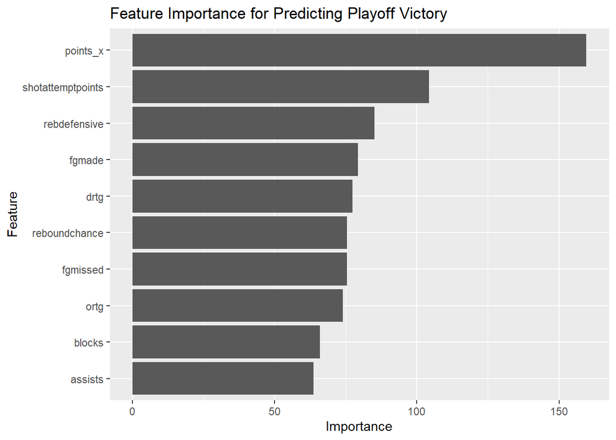

```r
# Visualize feature importance
ggplot(feature_importance_df, aes(x = reorder(feature, importance), y = importance)) +
  geom_bar(stat = "identity") +
  coord_flip() +
  labs(title = "Feature Importance for Predicting Playoff Victory", x = "Feature", y = "Importance")
```

```r
# Select the most important features
top_features <- feature_importance_df$feature[1:10]
print(paste("Top features for predicting playoff victory:", top_features))
```

```
##  [1] "Top features for predicting playoff victory: points_x"
##  [2] "Top features for predicting playoff victory: shotattemptpoints"
##  [3] "Top features for predicting playoff victory: rebdefensive"
##  [4] "Top features for predicting playoff victory: fgmade"
##  [5] "Top features for predicting playoff victory: drtg"
##  [6] "Top features for predicting playoff victory: reboundchance"
##  [7] "Top features for predicting playoff victory: fgmissed"
##  [8] "Top features for predicting playoff victory: ortg"
##  [9] "Top features for predicting playoff victory: blocks"
## [10] "Top features for predicting playoff victory: assists"
```

```r
# Predict series winner function
predict_series_winner <- function(team_a, team_b, model, scaler, team_data, selected_features) {
  team_a_data <- team_data %>%
    filter(off_team_name == team_a) %>%
    select(one_of(selected_features)) %>%
    summarise_all(mean, na.rm = TRUE) %>%
    unlist()

  team_b_data <- team_data %>%
    filter(off_team_name == team_b) %>%
    select(one_of(selected_features)) %>%
    summarise_all(mean, na.rm = TRUE) %>%
    unlist()

  if (length(team_a_data) == 0 || length(team_b_data) == 0) {
    print("Insufficient data for one or both teams. Please check the team names and data availability.")
    return(NULL)
  }

# Handle missing values
  team_a_data[is.na(team_a_data)] <- 0
  team_b_data[is.na(team_b_data)] <- 0

# Standardize data
  team_a_data <- predict(scaler, as.data.frame(t(team_a_data)))
  team_b_data <- predict(scaler, as.data.frame(t(team_b_data)))

# Predict each team's probability of winning the game
  team_a_prob <- predict(model, team_a_data, type = "prob")[, 2]
  team_b_prob <- predict(model, team_b_data, type = "prob")[, 2]

# Predict the number of games in the series (assuming the number of games is inversely proportional to win probability)
  result_counts <- matrix(0, nrow = 5, ncol = 5)
  colnames(result_counts) <- 0:4
  rownames(result_counts) <- 0:4

  for (i in 1:10000) {
    team_a_wins <- 0
    team_b_wins <- 0
    for (game in 1:7) {
      if (runif(1) < team_a_prob) {
        team_a_wins <- team_a_wins + 1
      } else {
        team_b_wins <- team_b_wins + 1
      }
      if (team_a_wins == 4 || team_b_wins == 4) {
        result_counts[as.character(team_a_wins), as.character(team_b_wins)] <- result_counts[as.character(team_a_wins), as.character(team_b_wins)] + 1
        break
      }
    }
  }

  return(result_counts)
}

# Simulate playoffs function
simulate_playoffs <- function(matchups, model, scaler, team_data, top_features) {
  next_round_teams <- c()
  round_probabilities <- list()
  round_results <- list()

  for (matchup in matchups) {
    team_a <- matchup[1]
    team_b <- matchup[2]
    result_counts <- predict_series_winner(team_a, team_b, model, scaler, team_data, top_features)
    if (is.null(result_counts)) {
      next
    }

  team_a_prob <- sum(result_counts[5, ]) / 10000
  team_b_prob <- sum(result_counts[, 5]) / 10000
  round_probabilities[[paste(team_a, "vs", team_b)]] <- c(team_a_prob, team_b_prob)
  round_results[[paste(team_a, "vs", team_b)]] <- result_counts

  winner <- ifelse(team_a_prob > team_b_prob, team_a, team_b)
  next_round_teams <- c(next_round_teams, winner)
}

  return(list(next_round_teams, round_probabilities, round_results))
}

# First round matchups
east_matchups <- list(
  c('Boston Celtics', 'Miami Heat'),
  c('New York Knicks', 'Philadelphia 76ers'),
  c('Milwaukee Bucks', 'Indiana Pacers'),
  c('Cleveland Cavaliers', 'Orlando Magic')
)

west_matchups <- list(
  c('Oklahoma City Thunder', 'New Orleans Pelicans'),
  c('Denver Nuggets', 'Los Angeles Lakers'),
  c('Minnesota Timberwolves', 'Phoenix Suns'),
  c('LA Clippers', 'Dallas Mavericks')
)

# First round
east_results <- simulate_playoffs(east_matchups, model, scaler, team_data, top_features)
west_results <- simulate_playoffs(west_matchups, model, scaler, team_data, top_features)

# Second round matchups
east_semi_final_matchups <- list(
  c(east_results[[1]][1], east_results[[1]][4]),
  c(east_results[[1]][2], east_results[[1]][3])
)

west_semi_final_matchups <- list(
  c(west_results[[1]][1], west_results[[1]][4]),
  c(west_results[[1]][2], west_results[[1]][3])
)

# Second round
east_semi_results <- simulate_playoffs(east_semi_final_matchups, model, scaler, team_data, top_features)
west_semi_results <- simulate_playoffs(west_semi_final_matchups, model, scaler, team_data, top_features)

# Conference finals matchups
east_final_matchup <- list(c(east_semi_results[[1]][1], east_semi_results[[1]][2]))
west_final_matchup <- list(c(west_semi_results[[1]][1], west_semi_results[[1]][2]))

# Conference finals
east_final_results <- simulate_playoffs(east_final_matchup, model, scaler, team_data, top_features)
west_final_results <- simulate_playoffs(west_final_matchup, model, scaler, team_data, top_features)

# Finals matchup
final_matchup <- list(c(east_final_results[[1]][1], west_final_results[[1]][1]))

# Finals
nba_final_results <- simulate_playoffs(final_matchup, model, scaler, team_data, top_features)

# Output results
print("\nEastern Conference Final:")
```

```
## [1] "\nEastern Conference Final:"
```

```r
print(east_final_results[[2]])
```

```
## $`Boston Celtics vs Indiana Pacers`
## [1] 0.6745 0.3255
```

```r
print("\nWestern Conference Final:")
```

```
## [1] "\nWestern Conference Final:"
```

```r
print(west_final_results[[2]])
```

```
## $`Oklahoma City Thunder vs Denver Nuggets`
## [1] 0.6033 0.3967
```

```r
print("\nNBA Final:")
```

```
## [1] "\nNBA Final:"
```

```r
print(nba_final_results[[2]])
```

```
## $`Boston Celtics vs Oklahoma City Thunder`
## [1] 0.6764 0.3236
```

```r
# Function to format results
format_results <- function(results, round_name) {
  formatted_results <- paste(round_name, "Results and Probabilities:\n")
  for (matchup in names(results)) {
    teams <- strsplit(matchup, " vs ")[[1]]
    team_a <- teams[1]
    team_b <- teams[2]
    prob <- results[[matchup]]
    formatted_results <- paste(formatted_results, paste(team_a, "vs", team_b), "\n")
    for (i in 0:4) {
      for (j in 0:4) {
        if (i == 4 || j == 4) {
          count <- prob[as.character(i), as.character(j)]
          if (count > 0) {
            formatted_results <- paste(formatted_results, sprintf("%s %d - %s %d: %.2f%%\n", team_a, i, team_b, j, count / 100))
          }
        }
      }
    }
    team_a_prob <- sum(prob[5, ]) / 10000
    team_b_prob <- sum(prob[, 5]) / 10000
    formatted_results <- paste(formatted_results, sprintf("%s wins %.2f%%, %s wins %.2f%%\n", team_a, team_a_prob * 100, team_b, team_b_prob * 100))
  }
  return(formatted_results)
}

# First round results
east_first_round_results <- format_results(east_results[[3]], "First Round (East)")
west_first_round_results <- format_results(west_results[[3]], "First Round (West)")

# Second round results
east_second_round_results <- format_results(east_semi_results[[3]], "Second Round (East)")
west_second_round_results <- format_results(west_semi_results[[3]], "Second Round (West)")

# Conference finals results
east_final_results_text <- format_results(east_final_results[[3]], "Conference Finals (East)")
west_final_results_text <- format_results(west_final_results[[3]], "Conference Finals (West)")

# Finals results
final_results_text <- format_results(nba_final_results[[3]], "Finals")
# Extract the final matchup probabilities
final_probabilities <- nba_final_results[[2]]
final_matchup <- names(final_probabilities)
final_probs <- unlist(final_probabilities[[1]])

# Determine the champion
champion <- ifelse(final_probs[1] > final_probs[2], strsplit(final_matchup, " vs ")[[1]][1], strsplit(final_matchup, " vs ")[[1]][2])

# Print the champion
print(paste("NBA Champion:", champion))
```

```
## [1] "NBA Champion: Boston Celtics"
```

```r
print(east_first_round_results)
```

```
## [1] "First Round (East) Results and Probabilities:\n Boston Celtics vs Miami Heat \n Boston Celtics 0 - Miami Heat 4: 3.15%\n Boston Celtics 1 - Miami Heat 4: 7.28%\n Boston Celtics 2 - Miami Heat 4: 10.74%\n Boston Celtics 3 - Miami Heat 4: 12.23%\n Boston Celtics 4 - Miami Heat 0: 11.37%\n Bost…
```

```r
print(west_first_round_results)
```

```
## [1] "First Round (West) Results and Probabilities:\n Oklahoma City Thunder vs New Orleans Pelicans \n Oklahoma City Thunder 0 - New Orleans Pelicans 4: 3.95%\n Oklahoma City Thunder 1 - New Orleans Pelicans 4: 9.13%\n Oklahoma City Thunder 2 - New Orleans Pelicans 4: 12.27%\n Oklahoma City Thunde…
```

```r
print(east_second_round_results)
```

```
## [1] "Second Round (East) Results and Probabilities:\n Boston Celtics vs Orlando Magic \n Boston Celtics 0 - Orlando Magic 4: 3.02%\n Boston Celtics 1 - Orlando Magic 4: 7.37%\n Boston Celtics 2 - Orlando Magic 4: 10.52%\n Boston Celtics 3 - Orlando Magic 4: 12.01%\n Boston Celtics 4 - Orlando Mag…
```

```r
print(west_second_round_results)
```

```
## [1] "Second Round (West) Results and Probabilities:\n Oklahoma City Thunder vs LA Clippers \n Oklahoma City Thunder 0 - LA Clippers 4: 4.16%\n Oklahoma City Thunder 1 - LA Clippers 4: 8.83%\n Oklahoma City Thunder 2 - LA Clippers 4: 11.72%\n Oklahoma City Thunder 3 - LA Clippers 4: 13.32%\n Oklah…
```

```r
print(east_final_results_text)
```

```
## [1] "Conference Finals (East) Results and Probabilities:\n Boston Celtics vs Indiana Pacers \n Boston Celtics 0 - Indiana Pacers 4: 3.11%\n Boston Celtics 1 - Indiana Pacers 4: 6.99%\n Boston Celtics 2 - Indiana Pacers 4: 10.87%\n Boston Celtics 3 - Indiana Pacers 4: 11.58%\n Boston Celtics 4 - I…
```

```r
print(west_final_results_text)
```

```
## [1] "Conference Finals (West) Results and Probabilities:\n Oklahoma City Thunder vs Denver Nuggets \n Oklahoma City Thunder 0 - Denver Nuggets 4: 4.02%\n Oklahoma City Thunder 1 - Denver Nuggets 4: 9.62%\n Oklahoma City Thunder 2 - Denver Nuggets 4: 12.60%\n Oklahoma City Thunder 3 - Denver Nugge…
```

```r
print(final_results_text)
```

```
## [1] "Finals Results and Probabilities:\n Boston Celtics vs Oklahoma City Thunder \n Boston Celtics 0 - Oklahoma City Thunder 4: 3.16%\n Boston Celtics 1 - Oklahoma City Thunder 4: 7.26%\n Boston Celtics 2 - Oklahoma City Thunder 4: 10.00%\n Boston Celtics 3 - Oklahoma City Thunder 4: 11.94%\n Bos…
```

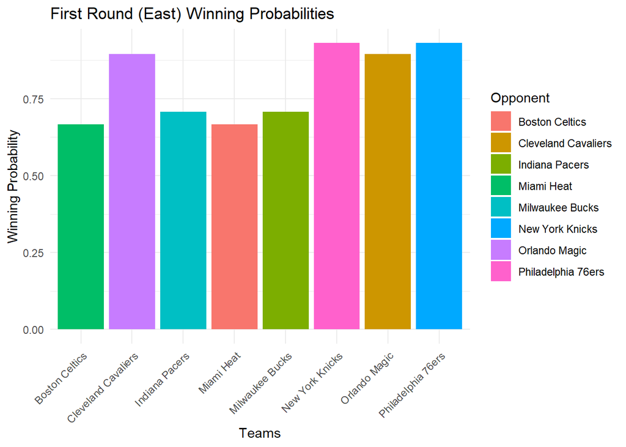

```r
plot_playoff_probabilities <- function(probabilities, title) {

# Convert the named list to a data frame
  prob_df <- do.call(rbind, lapply(names(probabilities), function(matchup) {
    teams <- strsplit(matchup, " vs ")[[1]]
    team_a <- teams[1]
    team_b <- teams[2]
    prob <- probabilities[[matchup]]
    data.frame(
      Team = c(rep(team_a, 2), rep(team_b, 2)),
      Opponent = c(rep(team_b, 2), rep(team_a, 2)),
      Probability = c(prob[1], prob[2], prob[1], prob[2])
    )
  }))

  ggplot(prob_df, aes(x = Team, y = Probability, fill = Opponent)) +
    geom_bar(stat = "identity", position = "dodge") +
    theme_minimal() +
    labs(title = title, x = "Teams", y = "Winning Probability") +
    theme(axis.text.x = element_text(angle = 45, hjust = 1))
}

# Plot each round's probabilities
plot_playoff_probabilities(east_results[[2]], "First Round (East) Winning Probabilities")
```

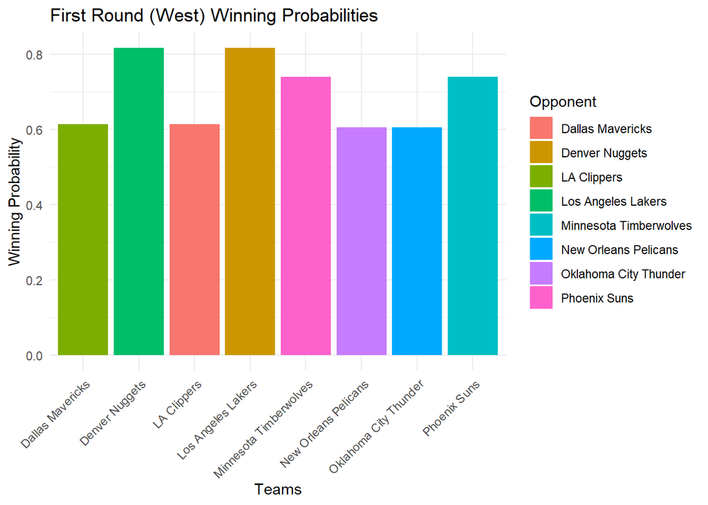

```r
plot_playoff_probabilities(west_results[[2]], "First Round (West) Winning Probabilities")
```

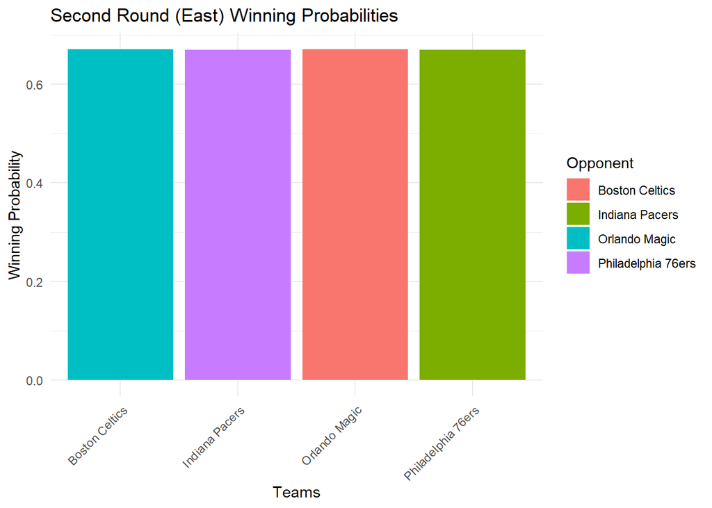

```r
plot_playoff_probabilities(east_semi_results[[2]], "Second Round (East) Winning Probabilities")
```

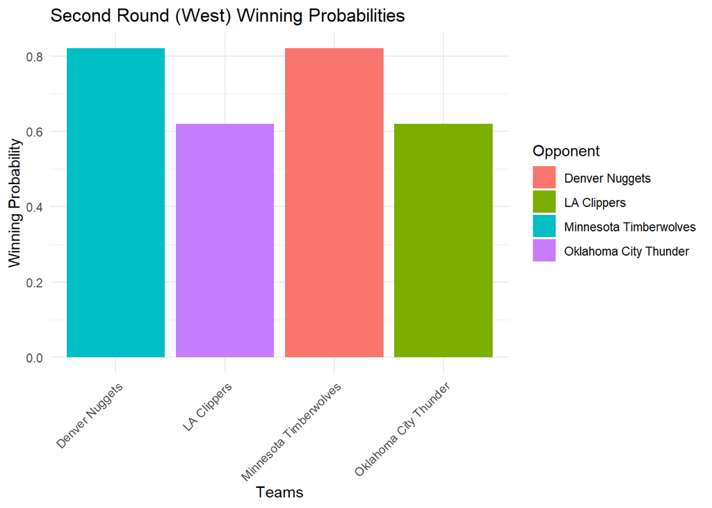

```r
plot_playoff_probabilities(west_semi_results[[2]], "Second Round (West) Winning Probabilities")
```

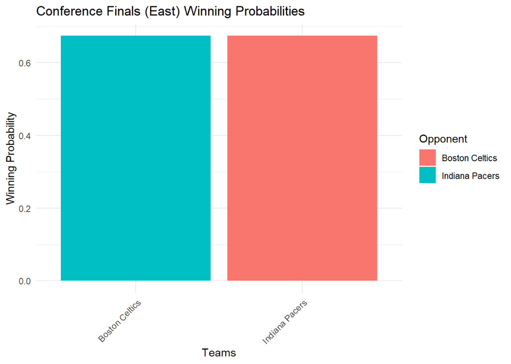

```r
plot_playoff_probabilities(east_final_results[[2]], "Conference Finals (East) Winning Probabilities")
```